# ArunKumar_Lab_EST

```python
import pandas as pd
import matplotlib.pyplot as plt
from sklearn.model_selection import train_test_split
import numpy as np
from sklearn.tree import DecisionTreeClassifier
from sklearn import metrics
```

### 1.Load the PIMA Indian Diabetes file into Python DataFrame. You may first download it to a local folder and then load it into Python dataframe. Let us assume the data frame is named “pima_df".

```python
colList = ['Pregnancies','Glucose','BloodPressure','SkinThickness','Insulin','BMI','DiabetesPedigreeFunction','Age','Outcome']
```

```python
pima_df=pd.read_csv("pima-indians-diabetes.data",names=colList)
```

```python
pima_df.head()
```

|  | Pregnancies | Glucose | BloodPressure | SkinThickness | Insulin | BMI | DiabetesPedigreeFunction | Age | Outcome |
| --- | --- | --- | --- | --- | --- | --- | --- | --- | --- |
| 0 | 6 | 148 | 72 | 35 | 0 | 33.6 | 0.627 | 50 | 1 |
| 1 | 1 | 85 | 66 | 29 | 0 | 26.6 | 0.351 | 31 | 0 |
| 2 | 8 | 183 | 64 | 0 | 0 | 23.3 | 0.672 | 32 | 1 |
| 3 | 1 | 89 | 66 | 23 | 94 | 28.1 | 0.167 | 21 | 0 |
| 4 | 0 | 137 | 40 | 35 | 168 | 43.1 | 2.288 | 33 | 1 |

### 2.It is always a good practice to eye-ball raw data to get a feel of the data in terms of number of structure of the file, number of attributes, types of attributes and a general idea of likely challenges in the dataset. You would notice that it is a comma separated file. There are no column names!. Check the associated folders and find out about each attribute the name. What information is available about the data.

```python
### Attribute Information:
# Pregnancies : Number of times pregnant
# Glucose : Plasma glucose concentration a 2 hours in an oral glucose tolerance test
# BloodPressure : Diastolic blood pressure (mm Hg)
# SkinThickness : Triceps skin fold thickness (mm)
# Insulin : 2-Hour serum insulin (mu U/ml)
# BMI : Body mass index (weight in kg/(height in m)^2)
# DiabetesPedigreeFunction : Diabetes pedigree function
# Age : Age (years)
# Outcome : Class variable (0 or 1)
```

### 3.Using univariate analysis check the individual attributes for their basic statistic such as central values, spread, tails etc. What are your observations (any two attributes)?

```python
%matplotlib inline
```

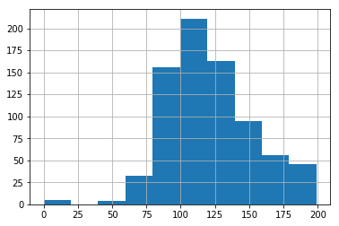

```python
pima_df['Glucose'].hist()
```

```python
pima_df['Glucose'].describe()
```

```
count    768.000000
mean     120.894531
std       31.972618
min        0.000000
25%       99.000000
50%      117.000000
75%      140.250000
max      199.000000
Name: Glucose, dtype: float64
```

```python
# The attribute Glucose has a positive correlation with the Outcome. And the data is normally distributed.
```

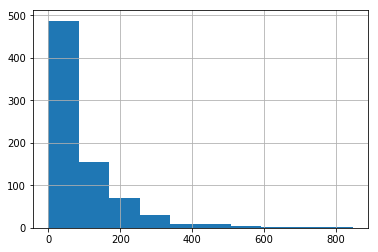

```python
pima_df['Insulin'].hist()
```

```python
pima_df['Insulin'].describe()
```

```
count    768.000000
mean      79.799479
std      115.244002
min        0.000000
25%        0.000000
50%       30.500000
75%      127.250000
max      846.000000
Name: Insulin, dtype: float64
```

```python
# The attribute Insulin has a positive correlation with the Outcome. And the data is positively skewed.
```

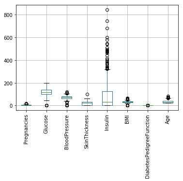

```python
colList = ['Pregnancies','Glucose','BloodPressure','SkinThickness','Insulin','BMI','DiabetesPedigreeFunction','Age']
pima_df.boxplot(column=colList,rot=90)
```

### 4.Using bivariate analysis check for useful relationships between attributes and attributes and the target class.

```python
print("Pregnancies Correlation :  ",pima_df['Outcome'].corr(pima_df['Pregnancies']))
print("Glucose Correlation :  ",pima_df['Outcome'].corr(pima_df['Glucose']))
print("BloodPressure Correlation :  ",pima_df['Outcome'].corr(pima_df['BloodPressure']))
print("SkinThickness Correlation :  ",pima_df['Outcome'].corr(pima_df['SkinThickness']))
print("Insulin Correlation :  ",pima_df['Outcome'].corr(pima_df['Insulin']))
print("BMI Correlation :  ",pima_df['Outcome'].corr(pima_df['BMI']))
print("DiabetesPedigreeFunction Correlation :  ",pima_df['Outcome'].corr(pima_df['DiabetesPedigreeFunction']))
print("Age Correlation :  ",pima_df['Outcome'].corr(pima_df['Age']))
```

```
Pregnancies Correlation :   0.221898153034
Glucose Correlation :   0.466581398307
BloodPressure Correlation :   0.0650683595503
SkinThickness Correlation :   0.0747522319183
Insulin Correlation :   0.130547954884
BMI Correlation :   0.292694662644
DiabetesPedigreeFunction Correlation :   0.173844065653
Age Correlation :   0.238355983027
```

```python
# The attributes Glucose,BMI,Age,DiabetesPedigreeFunction,Pregnancies has higher correlation with Outcome
```

### 5.Split the pima_df into training and test set in the ratio of 70:30 (Training:Test).

```python
pima_arr = pima_df.values
```

```python
x=pima_arr[:,0:8]
y=pima_arr[:,8]
```

```python
X_train,X_test,y_train,y_test = train_test_split(x,y,test_size=0.30,random_state=9)
```

### 6.Create the model using “entropy” method of reducing the entropy and fit it to training data.

```python
dt_model = DecisionTreeClassifier(criterion = 'entropy')
```

```python
dt_model.fit(X_train,y_train)
```

```
DecisionTreeClassifier(class_weight=None, criterion='entropy', max_depth=None,
            max_features=None, max_leaf_nodes=None,
            min_impurity_decrease=0.0, min_impurity_split=None,
            min_samples_leaf=1, min_samples_split=2,
            min_weight_fraction_leaf=0.0, presort=False, random_state=None,
            splitter='best')
```

### 7.Test the model on test data and what is the accuracy achieved. Capture the predicted values and do a crosstab.

```python
y_predict= dt_model.predict(X_test)
dScore = dt_model.score(X_test,y_test)
print(dScore)
print(metrics.confusion_matrix(y_test,y_predict))
```

```
0.688311688312
[[116  34]
 [ 38  43]]
```

### 8.Would you get the same result if you recreate the training and test data using random function?

```python
# If the 'random_state' function is not used in 'train_test_split' utility then every time the model score will be different.
```

### 9.Use regularization parameters of max_depth, min_sample_leaf to recreate the model. What is the impact on the model accuracy. How does regularization help?

```python
dt_model = DecisionTreeClassifier(criterion = 'entropy', max_depth = 5, min_samples_leaf=5 )
dt_model.fit(X_train, y_train)
y_predict= dt_model.predict(X_test)
dScore = dt_model.score(X_test,y_test)
print(dScore)
print(metrics.confusion_matrix(y_test,y_predict))
```

```
0.744588744589
[[129  21]
 [ 38  43]]
```

```python
# Regularization helps in imporving the accuracy score of the model.
```